# Sbrana_Advanced_Lander_Wind Farm Clean - Set Up

Sbrana A.

2026-06-05

# Introduction

The Mediterranean Sea is affected by a serious trend of overfishing, which poses a threat to the health and sustainability of its fish stocks. In order to address this critical issue, there is an urgent need for robust and effective management actions to ensure the long-term viability of fishery resources.

A spatially explicit bio-economic model that supports sustainable management by simulating fishing effort impacts. It integrates catch, stock, Vessel Monitoring System (VMS) data, and economic indicators, crucial for the Ecosystem Based Fisheries Management (EBFM). It also enables the Management Strategy Evaluation (MSE), testing different management scenarios to ensure robust, effective policies for long-term resource health and socio-economic benefits.

# 1. Initial set-up

In this section, we load the complete suite of R packages required to support our bio-economic modeling workflow. These libraries cover data restructuring (`dplyr`, `data.table`), spatial data manipulation (`sf`, `raster`, `terra`), automated plotting and cartography (`ggplot2`, `ggspatial`, `viridis`), and professional reporting extensions (`knitr`, `openxlsx`).

```r
Starting_time = Sys.time()
library(chron)
library(data.table)
library(dplyr)
library(fasterize)
library(fields)
library(ggmap)
library(ggplot2)
library(ggpubr)
library(ggrepel)
library(ggsci)
library(ggspatial)
library(gtsummary)
library(gridExtra)
library(irr)
library(knitr)
library(mapdata)
library(maps)
library(mapview)
library(marmap)
library(mgcv)
library(nnls)
library(openxlsx)
library(patchwork)
library(PBSmapping)
library(prioritizr)
library(progress)
library(raster)
library(reshape2)
library(rpart)
library(sf)
library(stringr)
library(terra)
library(tidyterra)
library(webr)
library(viridis)
library(png)
library(grid)
library(ggimage)
library(ggdendro)
```

## 1.1 Define the range of data inputs:

The preliminary step in this process is to define the range of data that will be loaded into the model, which should correspond to the specific case study that is to be analyzed. The following table sets out the parameters that may be switched in each case study.

```r
params_df = data.frame(Attribute = c(
      "years_to_submit",
      "species_to_submit",
      "gears_to_submit",
      "CS_gsas",
      "spatial_resolution_km"),
    Definition = c(
      "Year",
      "Species",
      "Gear",
      "GSA of the study area",
      "Spatial resolution (km)"),
    Options = c("2020; 2021; 2022; 2023",
      '"ARA"; "ARS"; "BOG"; "CBM"; "CTC"; "DGS"; "DPS"; "EDT"; "EOI"; "HKE"; "HMM"; "HOM"; "MON"; "MUR"; "MUT"; "NEP"; "SQE"; "SQM"',
      '"DRB"; "FPO"; "GND"; "GNS"; "GTR"; "HAR"; "LHM"; "LLD"; "LLS"; "OTB"; "OTM"; "PS_"; "PTM"; "TBB"',
      '"GSA04"; "GSA05"; "GSA06"; "GSA07"; "GSA08"; "GSA09"; "GSA10"; "GSA111"; "GSA112"; "GSA12"; "GSA13"; "GSA14"; "GSA15"; "GSA16"; "GSA17"; "GSA18"; "GSA19"; "GSA20"; "GSA21"; "GSA22"; "GSA23"; "GSA24"; "GSA25"; "GSA26"; "GSA29"',
      "1 km; 3 km; 5 km") )

kable(
  params_df,
  caption = "Input parameters.",
  booktabs = TRUE,
  longtable = TRUE
) |>
  kableExtra::kable_styling(full_width = FALSE)
```

Input parameters.

| Attribute | Definition | Options |
| --- | --- | --- |
| years_to_submit | Year | 2020; 2021; 2022; 2023 |
| species_to_submit | Species | “ARA”; “ARS”; “BOG”; “CBM”; “CTC”; “DGS”; “DPS”; “EDT”; “EOI”; “HKE”; “HMM”; “HOM”; “MON”; “MUR”; “MUT”; “NEP”; “SQE”; “SQM” |
| gears_to_submit | Gear | “DRB”; “FPO”; “GND”; “GNS”; “GTR”; “HAR”; “LHM”; “LLD”; “LLS”; “OTB”; “OTM”; “PS_”; “PTM”; “TBB” |
| CS_gsas | GSA of the study area | “GSA04”; “GSA05”; “GSA06”; “GSA07”; “GSA08”; “GSA09”; “GSA10”; “GSA111”; “GSA112”; “GSA12”; “GSA13”; “GSA14”; “GSA15”; “GSA16”; “GSA17”; “GSA18”; “GSA19”; “GSA20”; “GSA21”; “GSA22”; “GSA23”; “GSA24”; … |
| spatial_resolution_km | Spatial resolution (km) | 1 km; 3 km; 5 km |

## 1.2 Load general resources:

We load general reference frameworks and biological datasets to contextualize our core data. This involves importing the standard FAO ASFIS species list for scientific nomenclature matching, compiling species-specific bathymetric operational ranges, and mapping the geographical coordinates of regional landing ports.

```r
# FAO Species Sheet
fao3 = read.xlsx("Input file/ASFIS_sp_2019.xlsx")

# Depth ranges by species
ranges = read.csv("Input file/species_depth_range.csv")

# Coordinates of the harbours
Harbs =  read.csv("Input file/Harbs_coords.csv")
```

Next, we ingest the critical spatial layers defining our geographical context. This includes loading the national coastline bounds, the formal Case Study administrative boundaries (`CS_WF.shp`), high-resolution bathymetric basemaps for the Mediterranean, and the specific shapefiles designating the spatial planning layout of the offshore Wind Farm polygons.

```r
mp <- map_data("world", region = c("Italy"))
CS = read_sf("Set Ups/CS_WF.shp")
bathy = readRDS("Input file/med_bath.sqlitebathy.rData")
polygons_sf = st_read("Set Ups/WindFarm_Polygon.shp", quiet = TRUE) %>%  st_transform(crs = st_crs(CS_crs)) %>% mutate(id = "Wind Farm")
```

## 1.3 Load Fishery Dependent Information (FDI)

The database was developed to support the management of fishing effort management regimes. The FDI database offers a comprehensive overview of fishing effort across the EU. By collecting information about fishing capacity, effort, landings, and discards, it allows for comparison between regions at a detailed level (métier, gear).

**Table A.** Landings summary (Estimate landings in tonnes)

**Table G.** Effort summary (Effort in fishing days without spatial dimension)

```r
fdiA = readRDS("Input file/FDI/FDI_table_A_2020-2024.rData")
fdiG = read.csv("Input file/FDI/EU DCF Effort.csv")
```

## 1.4 Map of the study area:

We import and validate the main spatial grid (5 km cell resolution) constructed for this scenario. The grid is geometrically intersected with our Case Study boundaries, and cell centroids are calculated to sample precise depths from the bathymetric raster. Cells falling directly within the prospective wind farm perimeter are systematically flagged.

```r
grid_sf = st_make_valid(read_sf("Set Ups/Grid_5km_scenario.shp")) %>% rename(id_grid = id) %>% mutate(id_grid = as.character(id_grid)) %>%
  st_intersection(CS) %>%
  st_as_sf(crs = CS_crs)

grid_sf$id_grid[which(grid_sf$WF == 1)] <- paste0(grid_sf$id_grid[which(grid_sf$WF == 1)],"_WF")

grid_centroid = st_centroid(grid_sf)
depth <- -1 * get.depth(mat = bathy, x = st_coordinates(grid_centroid)[, c("X","Y")], locator = FALSE)$depth
grid_sf$depth = depth


map_xlim = st_bbox(grid_sf)[c(1,3)]
map_ylim = st_bbox(grid_sf)[c(2,4)]
```

Now, we *generate and plot the grid with relative depth*.

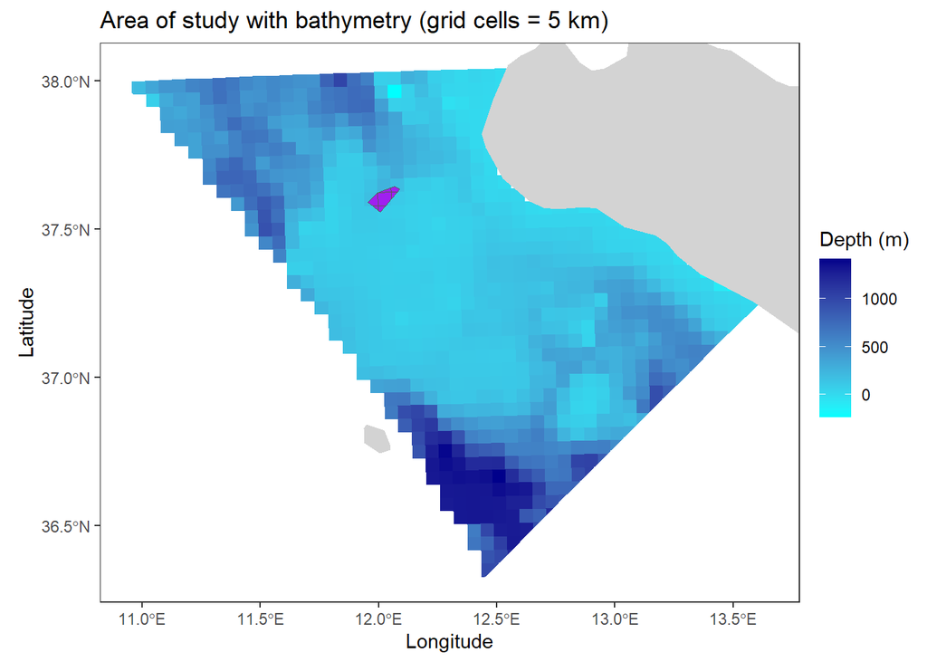

```r
ggplot() +
    geom_sf(data = grid_sf, aes(fill = depth), color = NA, lwd = 0.2) +
    geom_sf(data = grid_sf[which(grid_sf$WF == 1),], fill = "purple", fill = NA)+
    geom_polygon(data = mp, aes(long, lat, group = group), fill = "lightgray") +
    theme(panel.background = element_rect(fill = "white"),
        legend.position = "right",
        legend.title.position = "bottom") +
  scale_fill_gradient("Depth (m)", low = "cyan", high = "darkblue",
                      na.value = "NA")+
  xlab("Longitude") +
  ylab("Latitude") +
  ggtitle(paste0("Area of study with bathymetry (grid cells = ", spatial_resolution_km, " km)"))+
  theme_test() +
  coord_sf(xlim = map_xlim,
           ylim = map_ylim,
           expand = TRUE) #,
```

The spatial extent of the study area, as defined by the latitude and longitude coordinates, provides a valuable geographical context. The inclusion of the landmass in the northeastern section allows for a clear distinction between terrestrial and marine environments.

While the 5 km grid resolution provides a broad overview, higher resolution data could potentially reveal more intricate details of the seabed. This map serves as a useful foundation for further research, such as hydrodynamic modeling, sediment transport studies, or marine habitat mapping.

## 1.5 Species considered

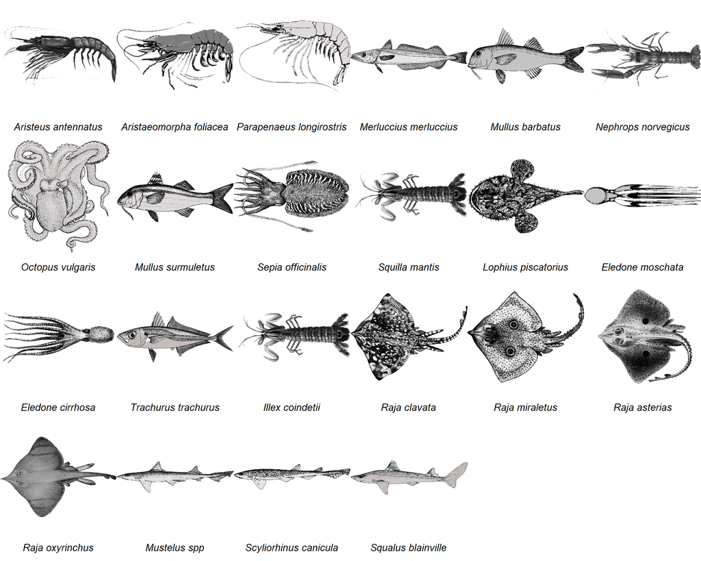

# 2. Effort data preprocessing

Prepare the spatial Effort data. Effort data for each year contain:

*Label code*

CFR

```
*Description*
```

Common Fleet Register

UTC

Coordinated Universal Time

YEAR

Year of relative fishing trips

MONTH

Month of relative fishing trips

SPEED

Speed of the vessels [km/h]

HEADING

Shipping direction

TRACK

Fishing trip

HARBOUR

Harbor of affiliation

INTERPOLATED

Binary: wheather the ping is interpolated or not

GSA

FAO Geographical Sub-Area

GFCM

General Fisheries Commission for the Mediterranean - GFCM

in3nm

Binary: is the point in the 3NM buffer zone

id

CFR + Track

fishing

[0 - 1] data for fishing - no fishing track

depth

Bathymetry of the seabed

Metier

Fishing activity by length over all

fishing_time

Period during which the boat was actively engaged in fishing activities.

Gear

Prevalent fishing gear

geometry

Parameter of the *sf* library

## 2.1 Prepare fishing track data (effort)

This script handles the heavy preprocessing of high-frequency satellite fishing tracks (VMS/AIS data) produced by VMSbase. The routine iterates through each year, isolates specified gears within our target GSAs, and eliminates low-activity vessels using an effort quantile filter. Crucially, it masks raw Common Fleet Register (CFR) codes with anonymous identifiers to ensure strict data compliance and privacy before saving the cleaned tracking list.

```r
FishTrack_sf_list = vector(mode = "list", length = length(years_to_submit))
FishTrack_stats = data.frame(year = years_to_submit, npoints = numeric(length(years_to_submit)))

# This is the data frame of the harbours
cfr_harbs_df = data.frame(CFR = numeric(0),
                          HARBOUR = character(0))

for(y in 1:length(years_to_submit)){

  FishTrack = readRDS(paste0("Input file/Fishing Track/", years_to_submit[y],
                          "_Interpolated_Tracks_withFishing.rData"))
  FishTrack$Gear = substr(FishTrack$Metier, 1, 3)

  # effort$Gear = ifelse(str_detect(effort$Gear, "_") == TRUE,
  #                      substr(effort$Gear, 1,
  #                             matrix(unlist(str_locate_all(effort$Gear,"_")), ncol = 2, byrow = TRUE)[,1]-1),
  #                      effort$Gear)
  FishTrack = FishTrack %>% filter(Gear %in% gears_to_submit)

  # First extract the harbours
  yh = unique(FishTrack %>% filter(HARBOUR != "", GSA %in% CS_gsas) %>% dplyr::select("CFR", "HARBOUR"))
  cfr_harbs_df = rbind(cfr_harbs_df, yh)

  FishTrack = FishTrack %>% filter(fishing_time > 0)
  FishTrack$MONTH = factor(month.name[FishTrack$MONTH], levels = month.name)
  FishTrack$YEAR = as.character(FishTrack$YEAR)
  FishTrack$CFR = as.character(FishTrack$CFR)

   # Reshape the effort as sf object
  FishTrack_sf = st_as_sf(FishTrack, coords  = c("LON", "LAT"), crs = st_crs(grid_sf))
  st_crs(FishTrack_sf) = st_crs(grid_sf)


  FishTrack_agg_CFR <- as.data.table(st_drop_geometry(FishTrack_sf))[, .(fishing_time = sum(fishing_time, na.rm = TRUE)), by = CFR]

  noCFR = FishTrack_agg_CFR %>% dplyr::filter(fishing_time < quantile(FishTrack_agg_CFR$fishing_time, quantile_Effort))

  FishTrack_sf = FishTrack_sf %>% dplyr::filter(!(CFR %in% noCFR$CFR))

  FishTrack_sf_list[[y]] = FishTrack_sf
  FishTrack_stats[y, "npoints"] = nrow(FishTrack_sf)

  rm(FishTrack, yh)
  gc()
}


saveRDS(FishTrack_sf_list , file = paste0(out_dir, "/FishTrack_sf_list.rData"))
saveRDS(cfr_harbs_df, file = paste0(out_dir, "/cfr_harbs_df.rData"))


# FishTrack_sf_list = readRDS(paste0(out_dir,"/FishTrack_sf_list.rData"))
#
# cfr_harbs_df = readRDS(paste0(out_dir,"/cfr_harbs_df.rData"))


FishTrack_clean = as.data.frame(st_drop_geometry(rbindlist(FishTrack_sf_list))) %>%
  group_by(CFR) %>%
  # filter(n_distinct(YEAR) == 4) %>%
  ungroup()

CFR_id = data.frame(CFR = as.character(unique(FishTrack_clean$CFR)))
CFR_id$CFR_anon <- paste0("boat_", seq_len(nrow(CFR_id)))
write.csv(CFR_id, "Set Ups/CFR_id.csv", row.names = F)


FishTrack_clean = FishTrack_clean %>%
  left_join(CFR_id) %>%
  mutate(CFR = CFR_anon,
         CFR_anon = NULL)

cfr_harbs_df_clean = cfr_harbs_df %>%
  mutate(CFR = as.character(CFR)) %>%
  left_join(CFR_id) %>%
  mutate(CFR = CFR_anon,
         CFR_anon = NULL) %>%
  drop_na()

saveRDS(FishTrack_clean, "Input file/FishTrack_clean.rData")
saveRDS(cfr_harbs_df_clean, "Input file/cfr_harbs_df_clean.rData")


fleet_register = read.csv("Input file/Fleet register.csv", sep = ";")
CFR_id = read.csv("Set Ups/CFR_id.csv") %>% mutate(CFR = as.character(CFR))

fleet_register_clean = fleet_register %>%
  mutate(CFR = as.character(CFR)) %>%
  inner_join(CFR_id) %>%
  mutate(CFR = CFR_anon,
         CFR_anon = NULL)
saveRDS(fleet_register_clean, "Input file/fleet_register_clean.rData")

remove(fleet_register)
```

## 2.2 Extract harbour from fishing tracks

To link operational dynamics to coastal communities, vessel tracking records are cross-referenced with harbor coordinates. By projecting the ports onto our active study grid, we clean and filter the data to retain only the functional linkages between active vessels and their true homeports, omitting sparse or unrepresentative records.

```r
FishTrack_clean = readRDS("Input file/FishTrack_clean.rData")
cfr_harbs_df = readRDS("Input file/cfr_harbs_df_clean.rData")

harbs_df <- Harbs %>%
  select(HARBOUR = PORT, Lon = LON, Lat = LAT) %>%
  distinct() %>%
  left_join(cfr_harbs_df, ., by = "HARBOUR") %>%
  select(HARBOUR, Lon, Lat) %>%
  distinct() %>%
  filter(complete.cases(Lon, Lat)) %>%
  st_as_sf(coords = c("Lon", "Lat"), crs = CS_crs)

cfr_harbs_df$HARBOUR = toupper(cfr_harbs_df$HARBOUR)

harbs_df <- harbs_df %>%
            st_intersection(grid_sf) %>%
            mutate(
              Lon = st_coordinates(.)[, "X"],
              Lat = st_coordinates(.)[, "Y"]) %>%
             select(
                HARBOUR,
                Lon,
                Lat) %>%
            st_drop_geometry()

cfr_harbs_df <- cfr_harbs_df %>%
         filter(CFR %in% FishTrack_clean$CFR) %>%
         filter(HARBOUR %in% unique(harbs_df$HARBOUR))
```

## 2.3 Define the final fleet with the harbour of each vessel

We reconstruct the comprehensive active fishing fleet profile by quantifying active fishing days and cumulative trip hours grouped by vessel, month, and year. This activity matrix is joined with official vessel characteristics (Length Over All - LOA, and engine power) from the fleet register. Vessels are partitioned into standard Length Classes (VL) and low-activity harbors are subsetted out to yield a robust, representative fleet baseline.

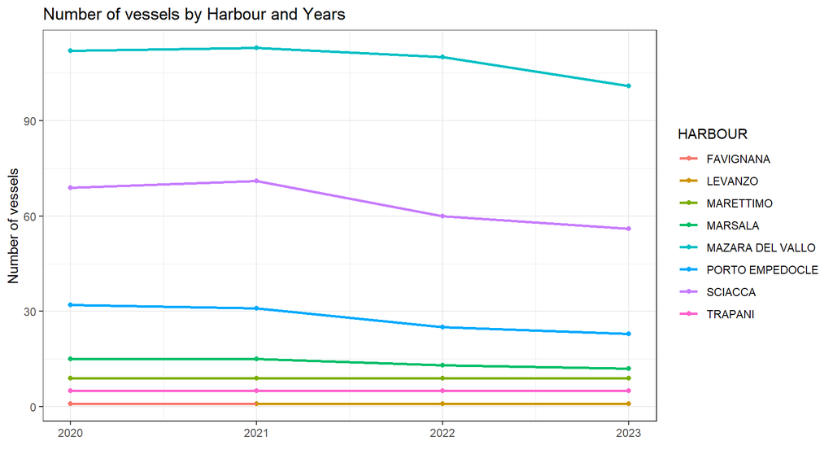

```r
fleet <- cfr_harbs_df %>%
  filter( HARBOUR %in% harbs_df$HARBOUR) %>%
  distinct() %>%
  mutate(n = 0)


fleet <- dcast(data = fleet, CFR ~ HARBOUR, value.var = "n")


FishTrack_clean = FishTrack_clean %>% filter(CFR %in% fleet$CFR)

FishTrack_clean <- FishTrack_clean %>%
  mutate(datetime = as.POSIXct(UTC * 86400,
                          origin = "1970-01-01",
                          tz = "UTC"),
    day = as.Date(datetime),
    hour = format(datetime, "%H:%M:%S"))


CFR_fish_day_hours <- FishTrack_clean %>%
  st_drop_geometry() %>%
  arrange(CFR, datetime) %>%
  group_by(CFR) %>%
  mutate(
    dt_h = as.numeric(difftime(lead(datetime),
                               datetime,
                               units = "hours"))
  ) %>%
  group_by(CFR,
           year = year(datetime),
           month = month(datetime)) %>%
  summarise(
    fishing_days = n_distinct(day),
    fishing_hours = sum(dt_h, na.rm = TRUE),
    .groups = "drop"
  )

CFR_fish_day_hours = CFR_fish_day_hours %>%
                      mutate(MONTH = month.name[month],
                             YEAR = as.character(year)) %>%
                      dplyr::select(-c(year,month))

process_cfr_data <- function(cfr_id) {
  # Monthly trip patterns
  xi <- FishTrack_clean %>%
    dplyr::filter(CFR == cfr_id) %>%
    dplyr::distinct(MONTH, YEAR, TRACK, Gear) %>%
    dplyr::mutate(n = 1)

  xit <- xi %>%
    dplyr::group_by(MONTH, YEAR, Gear) %>%
    dplyr::summarise(n = sum(n), .groups = "drop")


  # Primary harbor
  primary_harbor <- cfr_harbs_df %>%
    dplyr::filter(CFR == cfr_id) %>%
    dplyr::count(HARBOUR, sort = TRUE) %>%
    dplyr::slice(1) %>%
    dplyr::pull(HARBOUR)

  # Return formatted data
  tibble::tibble(
    CFR = cfr_id,
    HARBOUR = primary_harbor,
    GEAR = xit$Gear,
    YEAR = xit$YEAR,
    MONTH = xit$MONTH,
    ntrip = xit$n
  )
}

final_fleet <- purrr::map_dfr(fleet$CFR, process_cfr_data) %>%
  dplyr::group_by(CFR, HARBOUR, GEAR, MONTH, YEAR) %>%
  dplyr::summarise(ntrip = sum(ntrip), .groups = "drop")

final_fleet = final_fleet %>% left_join(CFR_fish_day_hours, by = c("CFR", "MONTH", "YEAR"))



# Vessel count by harbor
cfr_by_h <- final_fleet %>%
  distinct(CFR, HARBOUR, YEAR) %>%
  group_by(YEAR) %>%
  count(HARBOUR, name = "nvessel") %>%
  arrange(nvessel)



ggplot(data = cfr_by_h, aes(x = as.numeric(YEAR), y = nvessel, color = HARBOUR))+
  geom_point()+
  geom_line(size = 1)+
  xlab("")+
  theme_bw()+
  ggtitle("Number of vessels by Harbour and Years")+
  ylab("Number of vessels")
```

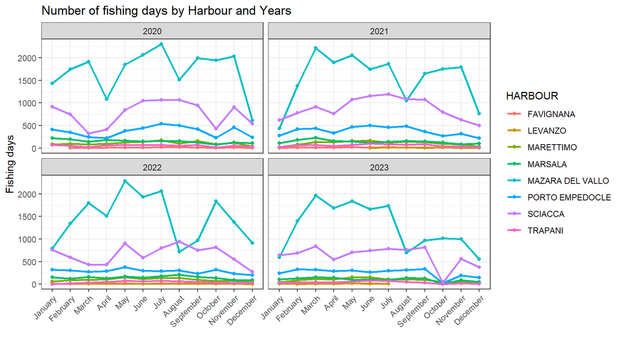

```r
final_fleet %>%
  mutate( MONTH = factor(MONTH, levels = month.name)) %>%
  group_by(MONTH, HARBOUR, YEAR) %>%
  summarise(fishdays = sum(fishing_days), .groups = "drop") %>%
  ggplot(aes(x = MONTH, y = fishdays, color = HARBOUR, group = HARBOUR)) +
  geom_point() +
  geom_line(linewidth = 1) +
  facet_wrap(~YEAR) +
  theme_bw() +
  xlab("") +
  ylab("Fishing days")+
  ggtitle("Number of fishing days by Harbour and Years")+
  theme(axis.text.x = element_text(angle = 45, hjust = 1))
```

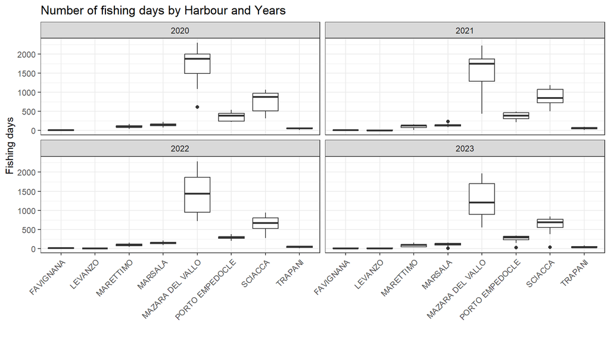

```r
final_fleet %>%
  mutate( MONTH = factor(MONTH, levels = month.name)) %>%
  group_by(MONTH, HARBOUR, YEAR) %>%
  summarise(fishdays = sum(fishing_days), .groups = "drop") %>%
  ggplot(aes(x = HARBOUR, y = fishdays)) +
  geom_boxplot() +
  facet_wrap(~YEAR) +
  theme_bw() +
  xlab("") +
  ylab("Fishing days")+
  ggtitle("Number of fishing days by Harbour and Years")+
  theme(axis.text.x = element_text(angle = 45, hjust = 1))
```

```r
# Filter harbors with too few vessels
low_days_harbors <- final_fleet %>%
  group_by(HARBOUR, YEAR) %>%
  summarise(fishdays = sum(fishing_days), .groups = "drop")

q1 <- quantile(low_days_harbors$fishdays, probs = 0.20, na.rm = TRUE)

low_days_harbors_filtered <- low_days_harbors %>%
  filter(fishdays <= q1) %>%
  pull(HARBOUR) %>% unique()

if (length(low_days_harbors_filtered) > 0) {
  final_fleet <- final_fleet %>%
    filter(!HARBOUR %in% low_days_harbors_filtered)
}

# Update cfr_by_h after filtering
cfr_by_h <- final_fleet %>%
  distinct(CFR, HARBOUR, YEAR) %>%
  group_by(YEAR) %>%
  count(HARBOUR, name = "nvessel") %>%
  arrange(nvessel)


# Final processing
FishTrack_clean <- FishTrack_clean %>%
  filter(CFR %in% unique(final_fleet$CFR))

fleet_register_clean = unique(readRDS("Input file/fleet_register_clean.rData"))

fleet_register_clean = fleet_register_clean %>%
                        select(CFR, loa,power_main)


# Join with fleet register and handle NA values
final_fleet <- final_fleet %>%
  mutate(CFR = as.character(CFR)) %>%
  left_join(fleet_register_clean, by = "CFR") %>%
  mutate(
    loa = ifelse(is.na(loa), mean(loa, na.rm = TRUE), loa),
    power_main = ifelse(is.na(power_main), mean(power_main, na.rm = TRUE), power_main),
    CFR = as.character(CFR)
  )

final_fleet = final_fleet %>%
 mutate(VL = cut(loa,
             breaks = c(0, 6, 12, 18, 24, 40, Inf),
             labels = c("VL0006", "VL0612", "VL1218", "VL1824", "VL2440", "VL40XX"),
             right = FALSE))

## tranform power main with zero value

final_fleet <- final_fleet %>%
  group_by(VL) %>%
  mutate(
    power_main = ifelse(
      power_main == 0,
      mean(power_main[power_main > 0], na.rm = TRUE),
      power_main)) %>%   ungroup()


# Prepare harbor data
harbs_df <- harbs_df %>%
  dplyr::filter(HARBOUR %in% final_fleet$HARBOUR) %>%
  dplyr::distinct() %>%
  dplyr::left_join(cfr_by_h, by = "HARBOUR")


harbs_df_sf = st_as_sf(harbs_df, coords = c("Lon","Lat"), crs = CS_crs)


# Create final fleet details with size categories

# Calculate fishing capacity
fishing_capacity <- final_fleet %>%
  group_by(HARBOUR, GEAR, VL, YEAR) %>%
  summarise(n_boat_tot = n_distinct(CFR), .groups = "drop")

final_fleet_detail_loa_power = final_fleet %>%
                                  group_by(CFR,HARBOUR,GEAR,VL) %>%
                                  summarise(loa = mean(loa),
                                            power_main = mean(power_main))

final_fleet_detail_fishdays_hours = final_fleet %>%
                         distinct(CFR,HARBOUR,GEAR,MONTH,YEAR,VL,fishing_days,fishing_hours)

saveRDS(FishTrack_clean , file = paste0(out_dir, "/FishTrack_clean.rData"))
saveRDS(final_fleet , file = paste0(out_dir, "/final_fleet.rData"))
saveRDS(fishing_capacity , file = paste0(out_dir, "/fishing_capacity.rData"))
saveRDS(final_fleet_detail_fishdays_hours , file = paste0(out_dir, "/final_fleet_detail_fishdays_hours.rData"))
saveRDS(final_fleet_detail_loa_power , file = paste0(out_dir, "/final_fleet_detail_loa_power.rData"))
```

### 2.3.1 Final fishing fleet

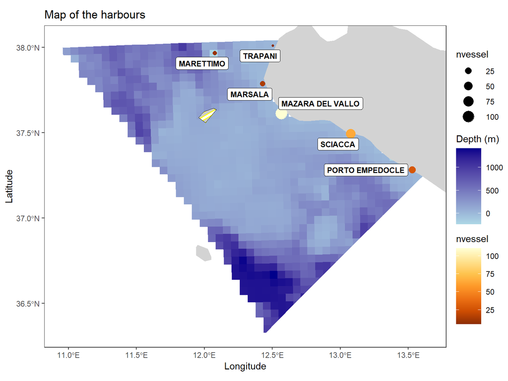

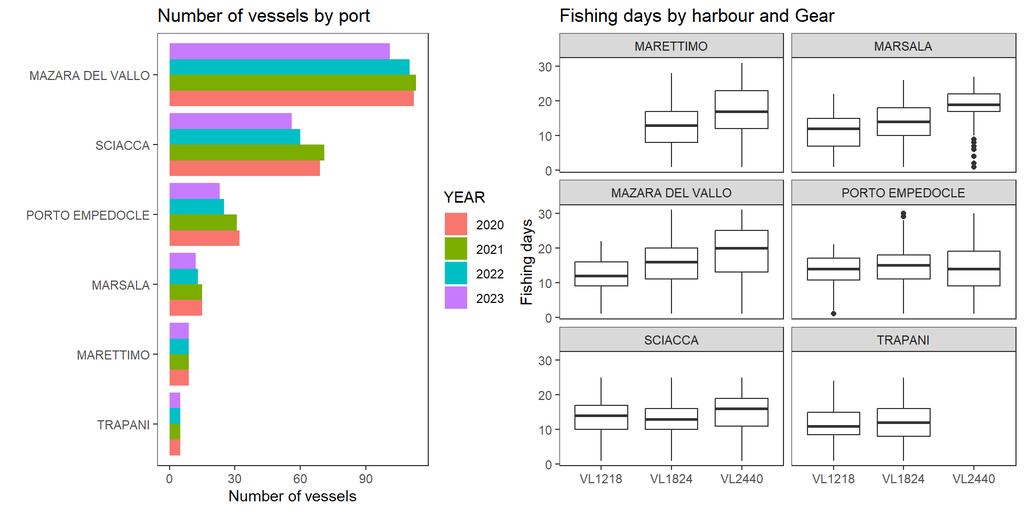

## 2.4 Overlap fishing track data on the grid

Continuous fishing tracks are converted into a discrete spatial distribution by intersecting tracking coordinates with the 5 km study grid cells. This step allows us to transition from raw trajectories to pixel-level aggregations of monthly fishing hours and operational days for each distinct vessel group.

```r
FishTrack_clean = FishTrack_clean %>%  st_as_sf()
FishTrack_clean = left_join(FishTrack_clean,unique(final_fleet_detail_fishdays_hours[,c("CFR","VL", "YEAR")]))
FishTrack_clean = FishTrack_clean %>%  mutate(VL = droplevels(VL))

FishTrack_sf_gridded_list <- FishTrack_clean  %>%  split(FishTrack_clean$YEAR)

FishTrack_sf_gridded_list <- purrr::map(FishTrack_sf_gridded_list, ~{
  filter(.x, CFR %in% unique(final_fleet$CFR)) %>%
    st_join(grid_sf["id_grid"]) %>%
    drop_na()
})

FishTrack_clean <- do.call(rbind, FishTrack_sf_gridded_list)


saveRDS(FishTrack_sf_gridded_list , file = paste0(out_dir, "/FishTrack_sf_gridded_list.rData"))
saveRDS(FishTrack_clean , file = paste0(out_dir, "/FishTrack_clean.rData"))

remove(FishTrack_sf_list)

gc()
```

```
##             used   (Mb) gc trigger   (Mb)   max used   (Mb)
## Ncells  21700682 1159.0   84241629 4499.0  122064413 6519.0
## Vcells 193037780 1472.8  889411761 6785.7 1111764701 8482.1
```

```r
FishTrack_fleet = FishTrack_clean %>%
                  st_drop_geometry %>%
                  arrange(CFR, datetime) %>%
                  group_by(CFR) %>%
                  mutate(dt_h = as.numeric(difftime(lead(datetime),
                                               datetime,
                                               units = "hours")),
                         TRACK = as.character(paste0("C",TRACK))) %>%
                  group_by(CFR,YEAR,MONTH,VL,day) %>%
                  summarise(n_TRACK  = n_distinct(TRACK),
                             fishing_hours = sum(dt_h, na.rm = TRUE), .groups = "drop")


FishTrack_grid = FishTrack_clean %>%
                  st_drop_geometry %>%
                  arrange(CFR, datetime) %>%
                  group_by(CFR) %>%
                  mutate(dt_h = as.numeric(difftime(lead(datetime),
                                               datetime,
                                               units = "hours")),
                         TRACK = as.character(paste0("C",TRACK))) %>%
                  group_by(CFR,YEAR,MONTH,VL,id_grid) %>%
                  summarise(n_TRACK = n_distinct(TRACK),
                            fishing_days = n_distinct(day),
                            fishing_hours = sum(dt_h, na.rm = TRUE),
                            .groups = "drop")

saveRDS(FishTrack_fleet, paste0(out_dir, "/Fleet_Track_per_day.Rdata"))
saveRDS(FishTrack_grid, paste0(out_dir, "/Fleet_Track_grid_days_hours.Rdata"))
```

## 2.5 Calculate effective effort (power_main * fishing_days)

Effective fishing effort is defined as the product of a vessel’s nominal engine power (kW) and its active fishing days within a given grid cell. This section aggregates this proxy across the grid and calculates the specific proportions of vessels and effort directly operating inside the proposed Wind Farm boundary compared to the surrounding open grounds.

```r
effort_gridded_agg_list = purrr::imap(FishTrack_sf_gridded_list, ~{
  .x %>%
    st_drop_geometry() %>%
    group_by(CFR, MONTH, Gear, id_grid, VL) %>%
     summarise(fishing_days = n_distinct(day), .groups = "drop") %>%
    mutate(power_main = final_fleet_detail_loa_power$power_main[match(CFR, final_fleet_detail_loa_power$CFR)]) %>%
    mutate(effort = power_main * fishing_days) %>%
    mutate(YEAR = .y)
})



effort_gridded_all = do.call(rbind, effort_gridded_agg_list) %>% drop_na()

effort_gridded_all = effort_gridded_all %>%
                      group_by(CFR, VL, YEAR) %>%
                      # filter(n_distinct(YEAR) == 4) %>%
                      ungroup()

df <- effort_gridded_all %>%
  mutate(
    WF = ifelse(grepl("[0-9]+_WF$", id_grid), "yes", "no")  )

ff = final_fleet_detail_fishdays_hours %>%
        group_by(CFR, HARBOUR, VL, YEAR) %>%
        summarise(n = n_distinct(HARBOUR)) %>%
        ungroup()

tab <- df %>%
  left_join(ff) %>%
  select(CFR, WF, HARBOUR, VL, YEAR) %>%
  distinct() %>%
  group_by(HARBOUR, VL, YEAR) %>%
  summarise(
    total = n_distinct(CFR),
    yes_n = n_distinct(CFR[WF == "yes"]),
    .groups = "drop"
  ) %>%
  mutate(
    label = ifelse(yes_n > 0,
                   paste0(total, " (", yes_n, ")"),
                   as.character(total))
  )

tab_final <- tab %>%
  select(YEAR, HARBOUR, VL, label) %>%
  pivot_wider(
    names_from = YEAR,
    values_from = label,
    values_fill = "0"
  ) %>%
  arrange(HARBOUR)

write.xlsx(tab_final, paste0(out_dir,"/Results/Table_Fig4.xlsx"))

kable(tab_final, caption = "Number of vessels by Harbour, Years and Length Class\n Vessels in the Wind Farm ()")
```

Number of vessels by Harbour, Years and Length Class Vessels in the Wind Farm ()

| HARBOUR | VL | 2020 | 2021 | 2022 | 2023 |
| --- | --- | --- | --- | --- | --- |
| MARETTIMO | VL1824 | 6 (1) | 6 (1) | 6 (1) | 6 |
| MARETTIMO | VL2440 | 2 (1) | 2 | 1 | 1 |
| MARSALA | VL1218 | 2 (1) | 2 (1) | 3 (2) | 3 (1) |
| MARSALA | VL1824 | 8 (4) | 6 (3) | 7 (3) | 7 (4) |
| MARSALA | VL2440 | 1 | 2 | 1 | 1 |
| MAZARA DEL VALLO | VL1218 | 3 (1) | 3 (1) | 3 (2) | 4 (2) |
| MAZARA DEL VALLO | VL1824 | 19 (10) | 20 (5) | 20 (6) | 17 (4) |
| MAZARA DEL VALLO | VL2440 | 73 (13) | 69 (2) | 75 (5) | 70 (10) |
| PORTO EMPEDOCLE | VL1218 | 3 | 3 | 2 | 1 |
| PORTO EMPEDOCLE | VL1824 | 16 | 14 | 11 | 9 |
| PORTO EMPEDOCLE | VL2440 | 3 | 2 | 3 | 3 |
| SCIACCA | VL1218 | 10 | 11 | 8 | 7 |
| SCIACCA | VL1824 | 56 | 56 | 47 | 43 |
| SCIACCA | VL2440 | 3 (1) | 3 (1) | 3 | 3 |
| TRAPANI | VL1218 | 3 | 3 | 3 | 3 |
| TRAPANI | VL1824 | 2 | 2 | 2 | 2 |

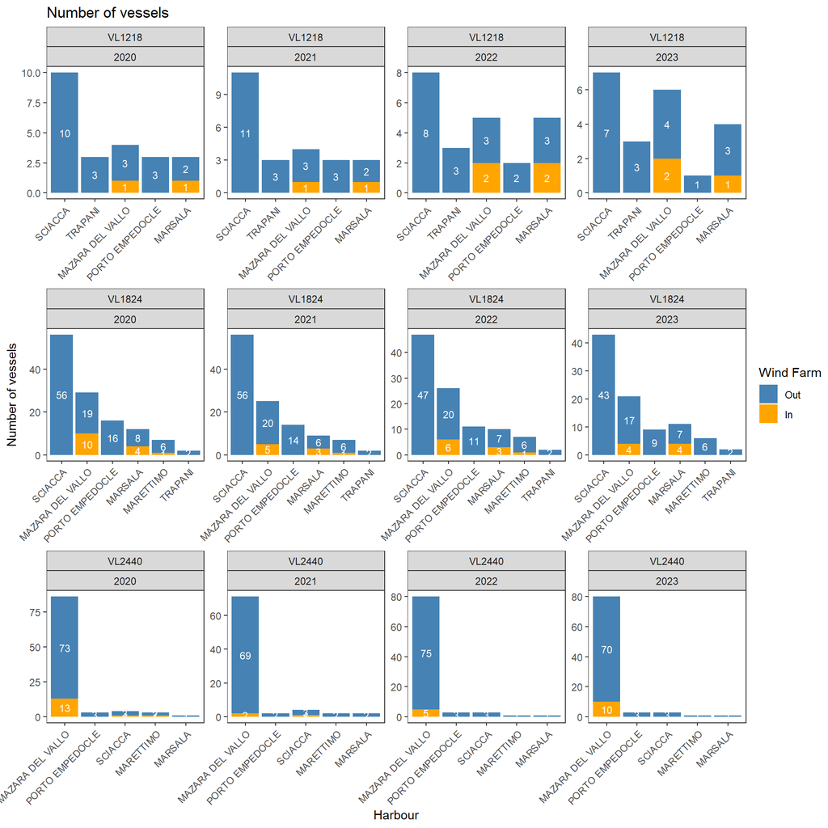

### 2.5.1 Check effort with FDI Effort (Table G)

To validate the reliability of our downscaled VMS tracking effort, we implement an external consistency check against official European FDI aggregate effort records (Table G). Subsequently, we compute a quarter-specific tuning rate to scale our gridded models to match official regional effort totals.

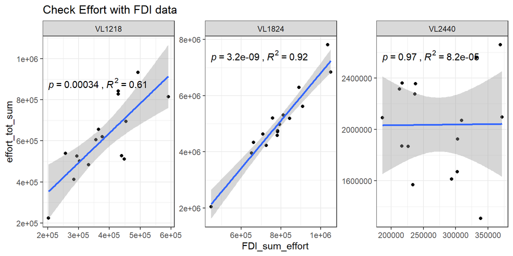

```r
fdi_effort = fdiG %>% filter(Country == "Italy",
                             Year %in% years_to_submit,
                             gear_type %in% gears_to_submit,
                             sub_region %in% CS_gsas,
                             Vessel.Length.Category %in% unique(effort_gridded_all$VL)) %>%
                rename(Gear = gear_type , VL = Vessel.Length.Category, YEAR = Year ) %>%
                mutate(Quarter = as.character(Quarter),
                       Total.kW.days.at.Sea = as.numeric(Total.kW.days.at.Sea),
                       YEAR = as.character(YEAR)) %>%
                group_by(Quarter,Gear, VL, YEAR ) %>%
                summarise(FDI_sum_effort = sum(Total.kW.days.at.Sea, na.rm = T)) %>%
                      ungroup()

effort_check = effort_gridded_all %>%
                  group_by(MONTH,Gear, VL, YEAR ) %>%
                  summarise(effort_tot = sum(effort)) %>%
                 mutate(Quarter = case_when(
                        MONTH %in% c("January", "February", "March") ~ 1,
                        MONTH %in% c("April", "May", "June") ~ 2,
                        MONTH %in% c("July", "August", "September") ~ 3,
                        MONTH %in% c("October", "November", "December") ~ 4 )) %>%
                ungroup() %>%
                group_by(Quarter,Gear, VL, YEAR ) %>%
                  summarise(effort_tot_sum = sum(effort_tot)) %>%
  mutate(Quarter = as.character(Quarter)) %>%
                  left_join(fdi_effort)


ggcomp_eff = effort_check %>%
ggplot(aes(x = FDI_sum_effort, y = effort_tot_sum))+
  geom_point()+
  geom_smooth(method = "lm")+
  facet_wrap(~ VL, scales = "free")+
  ggpubr::stat_cor(
    method = "pearson",
    label.x.npc = "left",
    label.y.npc = "top",
    aes(label = paste(..p.label.., ..rr.label.., sep = "~`,`~"))
  ) +
  theme_bw()+
  ggtitle("Check Effort with FDI data")

effort_check$rate = effort_check$FDI_sum_effort/effort_check$effort_tot_sum
if(length(which(is.na(effort_check$rate)))>0)
     effort_check$rate[which(is.na(effort_check$rate))] <- 1


print(ggcomp_eff)
```

```r
effort_gridded_all_list  <- split(effort_gridded_all, effort_gridded_all$YEAR)

for(y in 1:length(years_to_submit)){
  effort_gridded_all_y = effort_gridded_all_list[[y]]
  effort_gridded_all_y = effort_gridded_all_y %>%
                               mutate(Quarter = as.character(case_when(
                                 MONTH %in% c("January", "February", "March") ~ 1,
                                 MONTH %in% c("April", "May", "June") ~ 2,
                                 MONTH %in% c("July", "August", "September") ~ 3,
                                 MONTH %in% c("October", "November", "December") ~ 4 ))) %>%
                                 left_join(effort_check)


effort_gridded_all_y$effort_tune = effort_gridded_all_y$effort * effort_gridded_all_y$rate

effort_gridded_all_list[[y]] = effort_gridded_all_y %>% dplyr::select(-c(effort_tot_sum,FDI_sum_effort,rate))
}

ggsave(ggcomp_eff, filename = paste0(out_dir,"/Results/FigComp_Effort.jpeg"),width = 28, height = 18, units = "cm", dpi = 300)
```

### 2.5.2 Plot gridded effort by gear and month

Following the spatial adjustment and mapping of effort, the calibrated long-format effort records are cast into a wide-format matrix. This transformation structures the spatial cells as columns, which is a structural prerequisite for the mathematical optimization routines utilized in the subsequent LPUE downscaling phase.

[figure not shown]

Subsequently, the gridded fishing effort is transformed into a wide format, with a single cell allocated to each column. This is a crucial step in the estimation of the LPUE.

```r
effort_sf_gridded_list =  effort_gridded_all_list

effort_gridded_list_wide = vector(mode = "list", length = length(years_to_submit))

for(y in 1:length(years_to_submit)){

  # Extract and aggregate
  ey = st_drop_geometry(effort_sf_gridded_list[[y]])[, c("CFR", "YEAR", "MONTH","VL",
                                                         "Gear", "id_grid", "effort")]
  ey = aggregate(data = ey, effort ~ ., FUN = "sum", na.rm = TRUE)

  # Reshape to wide format
  eyw = reshape2::dcast(data = ey, CFR + YEAR + MONTH + VL+ Gear ~ id_grid, value.var = "effort")
  effort_gridded_list_wide[[y]] = eyw
}
```

# 3. Landings (or catch) data preprocessing

The second primary modeling block focuses on ingesting and processing commercial logbook datasets. Raw landing weights (in kilograms) are isolated for the target commercial species, selected gears, and specific Geographical Sub-Areas (GSAs). Vessel codes are matched with our fleet register identifiers to maintain anonymity while linking catch volumes to corresponding vessel size metrics.

```r
logbook_list = vector(mode = "list", length = length(years_to_submit))
logbook_stats = data.frame(year = years_to_submit, npoints = numeric(length(years_to_submit)))
CFR_id = read.csv("Set Ups/CFR_id.csv") %>% mutate(CFR = as.character(CFR))

for(y in 1:length(years_to_submit)){

  # Load the input related to Landings
  logbook <- unique(readRDS(paste0("Input file/Logbook/", years_to_submit[y], "_Monthly_Merged_LB.rData"))) %>% mutate(CFR = as.character(CFR))
  if(length(which(logbook$GSA_LB == "11.1"))>0)
     logbook$GSA_LB[which(logbook$GSA_LB == "11.1")] = "111"
   if(length(which(logbook$GSA_LB == "11.2"))>0)
     logbook$GSA_LB[which(logbook$GSA_LB == "11.2")] = "112"

  logbook_y = logbook %>%
                left_join(CFR_id) %>%
                mutate(CFR = CFR_anon,
                       CFR_anon = NULL) %>%
                      drop_na() %>%
               filter(Year == years_to_submit[y],
                 CFR %in% final_fleet$CFR,
                 Species %in% species_to_submit,
                 Gear %in% gears_to_submit,
                 GSA_LB %in% as.character(as.numeric(str_remove_all(CS_gsas, "GSA")))) %>%
                 rename(Mably = Kg, year = Year, gear_type = Gear, species = Species, sub_region = GSA_LB) %>%
                  mutate(CFR = as.character(CFR)) %>%
                left_join(unique(final_fleet_detail[,c("CFR","VL")]))

  logbook_y$sub_region = paste0("GSA", logbook_y$sub_region)
  logbook_list[[y]] = logbook_y

 }

logbook_ally = as.data.frame(do.call(rbind,logbook_list))

saveRDS(logbook_ally, "Input file/logbook_clean.rData")
```

## 3.1 Landings coverage by CS

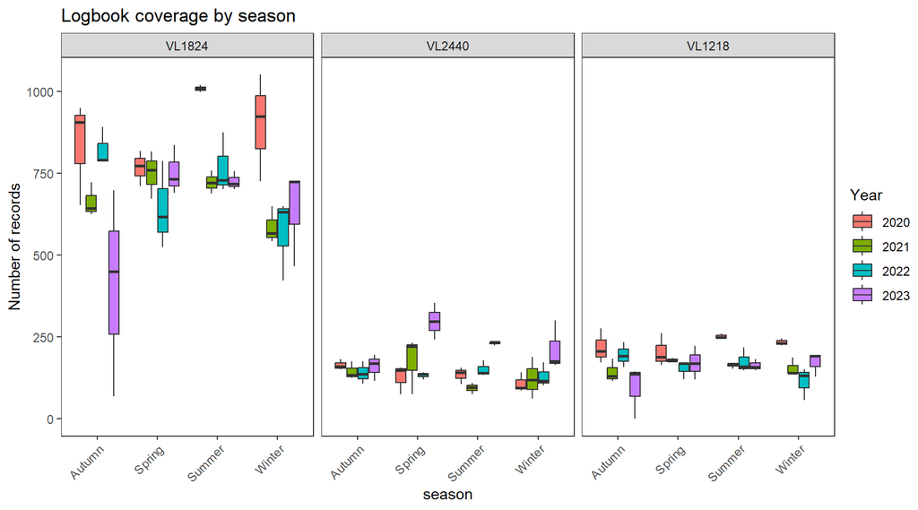

```r
logbook_ally = readRDS("Input file/logbook_clean.rData")
logbook_coverage = reshape2::melt(table(logbook_ally$year,
                                         logbook_ally$VL,
                                        logbook_ally$Month,
                                         logbook_ally$gear_type))
colnames(logbook_coverage) = c("Year","VL", "Month", "Gear", "value")

logbook_coverage$MONTH = month.name[logbook_coverage$Month]
logbook_coverage$MONTH = factor(logbook_coverage$MONTH,
                                 levels = c("January","February","March","April", "May", "June", "July", "August", "September", "October", "November", "December"))

logbook_coverage = logbook_coverage %>%
                       mutate(
                        season = case_when(
                          Month %in% c(12, 1, 2)  ~ "Winter",
                          Month %in% c(3, 4, 5)   ~ "Spring",
                          Month %in% c(6, 7, 8)   ~ "Summer",
                          Month %in% c(9, 10, 11) ~ "Autumn"))

print(logbook_coverage %>%
    mutate(Year = as.character(Year)) %>%
  ggplot(aes(x = season, y = value, fill = Year)) +
        geom_boxplot() +
        facet_wrap(~ VL) +
        theme_test() +
        theme(legend.position = "right", axis.text.x = element_text(angle = 45, vjust = 1,hjust = 1)) +
        ggtitle("Logbook coverage by season") +
        ylab("Number of records"))
```

## 3.2 Check with FDI data (Table A) for consistency

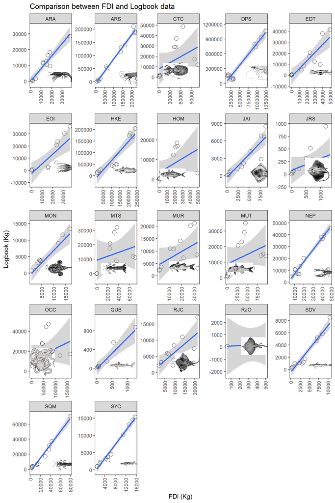

```r
# Check with FDI A
df_prod_FDI <- fdiA %>%
               filter(species %in% species_to_submit,
                                    year %in% years_to_submit,
                                    sub_region %in% CS_gsas,
                                    country_code == "ITA",
                                    gear_type %in% gears_to_submit,
                                    vessel_length %in% c("VL1218", "VL1824", "VL2440", "VL40XX")) %>%
                                    rename(VL = vessel_length)

df_prod_FDI <- df_prod_FDI %>%
                group_by(year,gear_type, species , sub_region , VL) %>%
                summarise(totwghtlandg = sum(totwghtlandg, na.rm = T),
                          totvallandg = sum(totvallandg, na.rm = T),.groups = "drop") %>%
                 mutate(FDI_kg = totwghtlandg * 1000,
                      Price_t = round(totvallandg/totwghtlandg,3),
                      Price_Kg = round(Price_t / 1000,3))


logbook_ally_agg = logbook_ally %>%
                    group_by(year,gear_type, species , sub_region , VL) %>%
                    summarise(Logbook_kg = round(sum(Mably, na.rm = TRUE),3),.groups = "drop")


df_compare = full_join(logbook_ally_agg, df_prod_FDI)

df_compare$rate = df_compare$FDI_kg/df_compare$Logbook_kg
if(length(which(is.na(df_compare$rate)))>0)
  df_compare$rate[which(is.na(df_compare$rate))] <- 1


dsub <- df_compare

panel_limits <- dsub %>%
    group_by(species) %>%
    summarize(
      xmin = min(Logbook_kg, na.rm = TRUE),
      xmax = max(Logbook_kg, na.rm = TRUE),
      ymin = min(FDI_kg, na.rm = TRUE),
      ymax = max(FDI_kg, na.rm = TRUE),
      .groups = "drop"
    )

  png_coords <- panel_limits %>%
    mutate(
      x = xmin + 0.95 * (xmax - xmin),
      y = ymin + 0.05 * (ymax - ymin),
      silhouette = paste0("Input file/png/", species, ".png")
    )

  gcomp <- ggplot(data = dsub, aes(x = FDI_kg, y = Logbook_kg)) +
    geom_point(pch = 21, size = 3) +
    geom_smooth(method = "lm") +
    facet_wrap(~ species, scales = "free", drop = FALSE) +
    theme_test() +
    ylab("Logbook (Kg)") +
    xlab("FDI (Kg)") +
    ggtitle(paste0("Comparison between FDI and Logbook data ")) +
    theme(
      legend.position = "bottom",
      axis.text.x = element_text(angle = 90, vjust = 0.5, hjust = 1)
    )

  gcomp <- gcomp +
    geom_image(
      data = png_coords,
      aes(x = x, y = y, image = silhouette),
      inherit.aes = FALSE,
      size = 0.4
    )

  print(gcomp)
```

```r
df_rate = df_compare %>%
            group_by(gear_type , VL, year , species) %>%
            summarise(rate = mean(rate))



landings_list  <- split(logbook_ally, logbook_ally$year)
# Tune landings
for(y in 1:length(years_to_submit)){
  landings_y = landings_list[[y]]

  landings_y = left_join(landings_y, df_rate)

  landings_y$Kg = landings_y$Mably * landings_y$rate


  landings_y = landings_y %>% dplyr::select(year,
                                     Month,
                                     CFR,
                                     gear_type,
                                     Metier,
                                     VL,
                                     species,
                                     sub_region,
                                     Kg)
  colnames(landings_y) = c("Year", "Month", "CFR", "Gear", "Metier", "VL", "Species", "GSA_LB", "Kg")
  landings_list[[y]] = landings_y
}

ggsave(gcomp, filename = paste0(out_dir,"/Results/FigComp_Landings.jpeg"),width = 28, height = 28, units = "cm", dpi = 300)
```

### 3.2.1 Plot aggregate landings

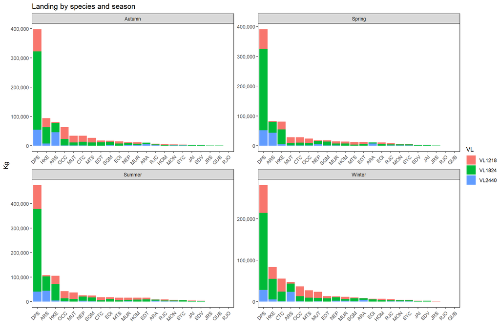

# 4. LPUE estimation

With clean, harmonized layers of spatial effort and validated landing weights, we proceed to estimate high-resolution Landings Per Unit Effort (LPUE). This process determines the spatial productivity of the fishing grounds by resolving where catches were likely extracted based on the observed distribution of fishing effort.

## 4.1 Initial estimation

We implement a multi-loop optimization routine that processes records by species, year, gear, length class, and month. The script applies biological constraints using species-specific depth grounds and filters out accidental or non-target trips via log-transformed quantile thresholds.

Because commercial logbooks record total landings (`Kg`) as a monthly aggregated per vessel without explicit geographical tracking, this routine applied a proportional spatial allocation algorithm using VMS/AIS effort as a proxy.

The routine identified the spatial grid columns, replaced missing values, and computed the total cumulative effort exerted by each vessel across all cells. It then distributed the aggregated logbook landings to individual grid cells based on the proportion of local-to-total fishing effort (`Kg * effort_cell / effort_tot`).

```r
# Set up the data frame for the LPUE

df_lpue = data.frame(YEAR = numeric(0),
                     species = character(0),
                     MONTH = factor(levels = month.name),
                     VL = character(0),
                     Gear = character(0),
                     id_grid = character(0),
                     LPUE_grid = numeric(0))


# Define the depth range
id_grid_potential_grounds = vector(mode = "list", length = length(species_to_submit))

for(s_index in 1:length(species_to_submit)) {
  minD = ranges$minD[which(ranges$Species == species_to_submit[s_index])]
  maxD = ranges$maxD[which(ranges$Species == species_to_submit[s_index])]
  id_grid_potential_grounds[[s_index]] <- grid_sf %>%
    filter(depth <= maxD, depth >= minD,
           id_grid %in% unique(effort_gridded_all$id_grid))

}

# =========================================================
# STORAGE OUTPUT
# =========================================================

lpue_list <- list()
counter <- 1


total_iterations <- length(species_to_submit) * length(years_to_submit)

# pb <- txtProgressBar(
#   min = 0,
#   max = total_iterations,
#   style = 3
# )

progress_counter <- 0

# =========================================================
# LOOP SPECIES
# =========================================================

for(s_index in seq_along(species_to_submit)) {

  species_i <- species_to_submit[s_index]

  # grounds specie
  grounds_i <- id_grid_potential_grounds[[s_index]]$id_grid

  # =======================================================
  # LOOP YEARS
  # =======================================================

  for(y in seq_along(years_to_submit)) {

    year_i <- years_to_submit[y]

    # -----------------------------------------------------
    # UPDATE PROGRESS BAR
    # -----------------------------------------------------

    progress_counter <- progress_counter + 1

    # setTxtProgressBar(pb, progress_counter)

    # cat(
    #   "\nSpecies:", species_i,
    #   "| Year:", year_i,
    #   "| Progress:",
    #   round(progress_counter / total_iterations * 100, 1),
    #   "%\n"
    # )

    # -----------------------------------------------------
    # LANDINGS
    # -----------------------------------------------------

    Ls <- landings_list[[y]] %>%
      dplyr::filter(
        Species == species_i,
        Gear %in% gears_to_submit,
        GSA_LB %in% CS_gsas
      ) %>%
      tidyr::drop_na()

    # skip se vuoto
    if(nrow(Ls) == 0) next

    # aggregazione
    Ls <- Ls %>%
      dplyr::group_by(CFR, Year, Month, VL) %>%
      dplyr::summarise(
        Kg = sum(Kg, na.rm = TRUE),
        .groups = "drop"
      )

    # -----------------------------------------------------
    # EFFORT
    # -----------------------------------------------------

    Es <- effort_gridded_list_wide[[y]]

    actual_id_grounds <- intersect(
      grounds_i,
      colnames(Es)
    )

    keep_cols <- c(
      "CFR", "YEAR", "MONTH",
      "Gear", "VL",
      actual_id_grounds
    )

    Es <- Es[, keep_cols]

    cfleet_logit <- intersect(Ls$CFR, Es$CFR)

    if(length(cfleet_logit) == 0) next

    # filtra
    Es <- Es %>%
      dplyr::filter(CFR %in% cfleet_logit)

    Ls <- Ls %>%
      dplyr::filter(CFR %in% cfleet_logit)

    # -----------------------------------------------------
    # FORMAT LANDINGS
    # -----------------------------------------------------

    Ls <- data.frame(
      CFR   = as.character(Ls$CFR),
      VL    = as.character(Ls$VL),
      MONTH = factor(
        month.name[Ls$Month],
        levels = month.name
      ),
      Kg    = Ls$Kg
    )

    # -----------------------------------------------------
    # JOIN
    # -----------------------------------------------------

    logit.join <- dplyr::inner_join(
      Ls %>% dplyr::select(CFR, MONTH, VL, Kg),
      Es[, !(colnames(Es) %in% "YEAR")]
    )

    if(nrow(logit.join) == 0) next

    # -----------------------------------------------------
    # LOOP GEARS
    # -----------------------------------------------------

    gears_present <- unique(logit.join$Gear)

    for(g in seq_along(gears_present)) {

      gear_i <- gears_present[g]

      logit.join.g <- logit.join %>%
        dplyr::filter(Gear == gear_i)

      if(nrow(logit.join.g) == 0) next

      # threshold logit
      q01logit_s <- 10^quantile(
        log10(Ls$Kg),
        quantile_Logit,
        na.rm = TRUE
      )

      # livelli presenti
      vls_i <- unique(logit.join.g$VL)

      # ---------------------------------------------------
      # LOOP VL
      # ---------------------------------------------------

      for(v in seq_along(vls_i)) {

        vl_i <- vls_i[v]

        logit.join.g.v <- logit.join.g %>%
          dplyr::filter(VL == vl_i)

        if(nrow(logit.join.g.v) == 0) next

        months_i <- unique(logit.join.g.v$MONTH)

        # -------------------------------------------------
        # LOOP MONTH
        # -------------------------------------------------

        for(m in seq_along(months_i)) {

          month_i <- months_i[m]

          # filtro finale
          logit.join.g.m <- logit.join.g.v %>%
            dplyr::filter(
              MONTH == month_i,
              Kg > q01logit_s
            )

          if(nrow(logit.join.g.m) <= 1) next

          # -----------------------------------------------
          # LPUE
          # -----------------------------------------------

          lpue <- getLPUE(logit.join.g.m)

          if(is.null(lpue) || nrow(lpue) == 0) next

          # -----------------------------------------------
          # OUTPUT
          # -----------------------------------------------

          n_lpue <- nrow(lpue)

          lpue_list[[counter]] <- data.frame(
            YEAR    = rep(year_i, n_lpue),
            species = rep(species_i, n_lpue),
            lpue
          )

          counter <- counter + 1

        } # end month

      } # end VL

    } # end gear

  } # end year

} # end species


# =========================================================
# CLOSE PROGRESS BAR
# =========================================================

# close(pb)

# =========================================================
# FINAL BIND
# =========================================================

df_lpue <- dplyr::bind_rows(lpue_list)

saveRDS(df_lpue,paste0(out_dir,"/df_lpue.rData"))
```

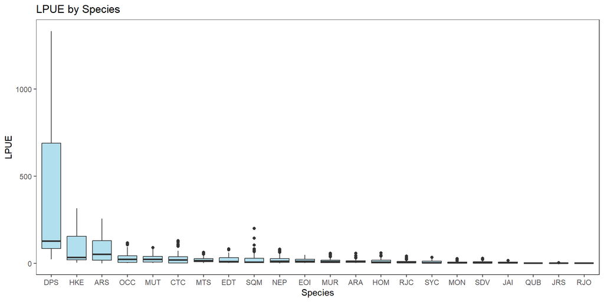

### 4.1.2 Plot Spatial LPUE by Gear and Species

```r
df_lpue_sum = df_lpue %>%
                  group_by(YEAR, MONTH, species , Gear , VL , id_grid) %>%
                  summarise(LPUE_grid = sum(LPUE_grid, na.rm = T)) %>%
                  group_by(species ,Gear, VL ,  id_grid) %>%
                  summarise(LPUE_grid = round(mean(LPUE_grid, na.rm = T),2))




grid_sf_lpue <- inner_join(grid_sf, df_lpue_sum)

png_coords <- df_lpue %>% dplyr::select(species) %>%
  group_by(species) %>%
  summarize(
    x = 13,
    y = 36.5,
    .groups = "drop"
  ) %>%
  mutate(silhouette = paste0(wd_set,"Input file/png/", species, ".png"))



for(s_index in 1:length(species_to_submit)){ # Species

  fmaplpue = grid_sf_lpue %>%
              filter(species == species_to_submit[s_index]) %>%
        ggplot() +
        geom_polygon(data = mp, aes(long, lat, group = group),
                     fill = "lightgray") +
        geom_sf(aes(fill = LPUE_grid),
                colour = NA) +
        scale_fill_viridis_c("LPUE (Kg/h/m)", option = "plasma", na.value = "NA") +
        xlab("Longitude") + ylab("Latitude") +
        theme_test() +
        theme(panel.background = element_rect(fill = "white"),
              legend.position = "bottom", legend.key.width=unit(1,"cm"),
              plot.title = element_text(size = 12), panel.spacing =unit(0.5,"cm")) +
        facet_wrap(~ VL) +
        coord_sf(xlim = map_xlim,
                 ylim = map_ylim,
                 expand = TRUE) +
          geom_image(data = png_coords %>% filter(species == species_to_submit[s_index]),
             aes(x = x, y = y, image = silhouette),
             inherit.aes = FALSE,
             size = 0.4) +
    ggtitle(
  bquote(
    .(species_to_submit[s_index]) ~ "-" ~
    italic(.(fao3$Scientific_name[
      which(fao3$`3A_CODE` == species_to_submit[s_index])
    ]))
  )
)


  ggsave(fmaplpue, filename = paste0(out_dir,"/Results/Fig6_",species_to_submit[s_index],".jpeg"),width = 22, height = 14, units = "cm", dpi = 300)
}
```

## 4.2 Get spatial landings and check with FDI data (Table A) - estimation of raising parameters

- FDI price = value/landings

```r
df_lpue$YEAR = as.character(df_lpue$YEAR)

df_prod = df_lpue %>%
           mutate(Quarter = as.character(case_when(
                                 MONTH %in% c("January", "February", "March") ~ 1,
                                 MONTH %in% c("April", "May", "June") ~ 2,
                                 MONTH %in% c("July", "August", "September") ~ 3,
                                 MONTH %in% c("October", "November", "December") ~ 4 )))

df_prod_agg <- df_prod %>%
      group_by(YEAR, Quarter, Gear,VL, species) %>%
      summarise(landings = round(
                  sum(landing_grid, na.rm = TRUE),2),
                .groups = "drop")

df_prod_agg$landings[df_prod_agg$landings == 0] <- 1

# Compare with FDI A
df_prod_FDI =  fdiA %>%
               filter(species %in% species_to_submit,
                                    year %in% years_to_submit,
                                    sub_region %in% CS_gsas,
                                    country_code == "ITA",
                                    gear_type %in% gears_to_submit,
                                    vessel_length %in% c("VL1218", "VL1824", "VL2440", "VL40XX")) %>%
                                    rename(VL = vessel_length,
                                           Quarter = quarter,
                                           YEAR = year,
                                           Gear = gear_type) %>%
                    mutate(YEAR = as.character(YEAR),
                           Quarter = as.character(Quarter))

df_prod_FDI <- df_prod_FDI %>%
                group_by(YEAR,Quarter,Gear, species , sub_region , VL) %>%
                summarise(totwghtlandg = sum(totwghtlandg, na.rm = T),
                          totvallandg = sum(totvallandg, na.rm = T),.groups = "drop") %>%
                 mutate(FDI_kg = totwghtlandg * 1000,
                      Price_t = round(totvallandg/totwghtlandg,3),
                      Price_Kg = round(Price_t / 1000,3))


df_compare = inner_join(df_prod_agg, df_prod_FDI)

df_compare$rate = df_compare$FDI_kg/df_compare$landings

df_compare_long = df_compare %>%
                dplyr::select(YEAR,Quarter, Gear, VL,  species, landings, FDI_kg) %>%
      melt(id.vars = c("YEAR","Quarter" ,"Gear", "VL", "species"))


df_compare_long = df_compare_long %>% mutate(source = recode(variable,
                                         "landings" = "MODEL",
                                         "FDI_kg" = "FDI"))

# mean_rates = aggregate(data = df_compare,
#                        rate ~ YEAR + Gear + VL+ species, FUN = "mean")
```

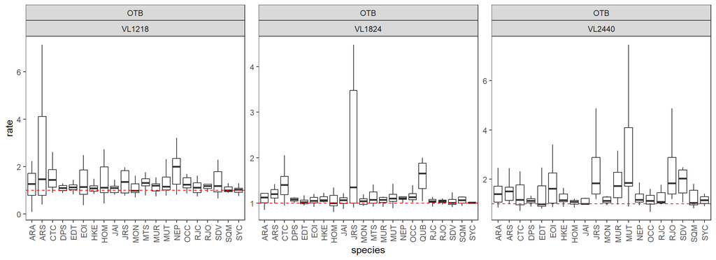

```r
gbox = ggplot(data = df_compare,
       aes(x = species, y = rate)) +
  geom_boxplot(outliers = FALSE) +
  facet_wrap(~ Gear+VL, nrow = 1, scales = "free") +
  geom_hline(yintercept = 1, colour = "red", linetype = 2) +
  theme_test() +
  theme(axis.text.x = element_text(angle = 90, vjust = 0.5, hjust=1))

print(gbox)
```

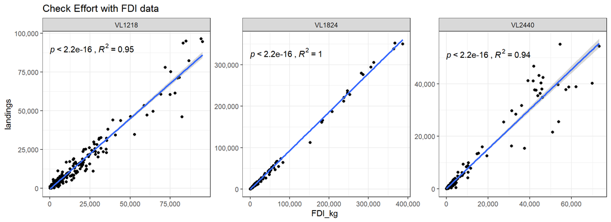

```r
ggcomp_land = df_compare %>%
ggplot(aes(x = FDI_kg   , y = landings ))+
  geom_point()+
  geom_smooth(method = "lm")+
  facet_wrap(~ VL, scales = "free")+
  ggpubr::stat_cor(
    method = "pearson",
    label.x.npc = "left",
    label.y.npc = "top",
    aes(label = paste(..p.label.., ..rr.label.., sep = "~`,`~"))
  ) +
  scale_y_continuous(labels = scales::label_comma())+
  scale_x_continuous(labels = scales::label_comma())+
  theme_bw()+
  ggtitle("Check Effort with FDI data")


print(ggcomp_land)
```

```r
df_prod_rescaled = df_prod %>%
                      left_join(df_compare, by = c("YEAR","species","VL","Gear","Quarter" )) %>%
                      mutate(landings_res = landing_grid * rate, na.rm = T)
```

# 5 Economic Indicators

## 5.1 Calculate revenues and compare with AER landing FAO

By multiplying our rescaled high-resolution spatial landings by the corresponding market prices extracted from FDI financial records, we generate downscaled economic indicators. This step provides explicit spatial representations of gross fishing revenues and value-based LPUE (vLPUE) across individual grid cells.

```r
full_model = df_prod_rescaled %>%
             mutate(value_of_landings = landings_res * Price_Kg,
                     vLPUE = LPUE_grid * Price_Kg) %>%
              drop_na()


saveRDS(full_model,paste0(out_dir,"/df_value_of_landings.rData"))
```

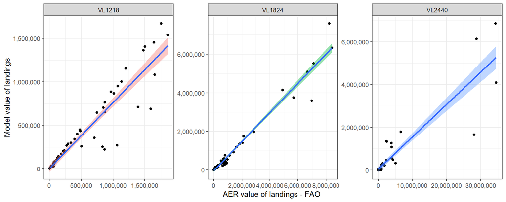

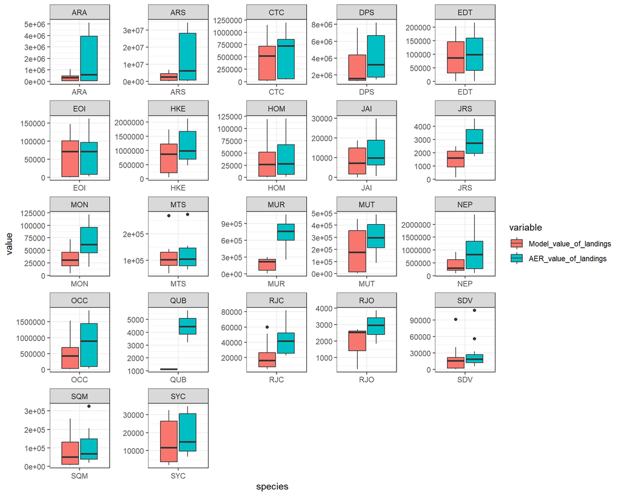

```r
AER_land = read.xlsx("Input file/STECF_25 07_Landings_fao.xlsx",sheet = 2)
AER_land_CS = AER_land %>%
                filter(country_name %in% "Italy",
                       year %in% years_to_submit,
                       fishing_tech %in% fts,
                       sub_reg %in% "sa 16",
                       species_code %in% species_to_submit) %>%
  dplyr::select(year,vessel_length,variable_code,value,species_code, unit) %>%
                rename(YEAR = year,species = species_code,VL = vessel_length) %>%
                mutate(YEAR = as.character(YEAR))

AER_land_CS_sel = AER_land_CS %>%
                  dcast(YEAR+species+VL~variable_code, value.var = "value")


full_model_agg = full_model %>%
                  group_by(YEAR,species,VL) %>%
                  summarise(value_of_landings_sum = sum(value_of_landings))

eco_check = full_model_agg %>%
              left_join(AER_land_CS_sel) %>%
              mutate(rate = totvallandg/value_of_landings_sum)

ggplot(eco_check, aes(x = totvallandg, y = value_of_landings_sum, fill = VL))+
  geom_point()+
  geom_smooth(method = "lm")+
  scale_x_continuous(labels = scales::label_comma())+
  scale_y_continuous(labels = scales::label_comma())+
  facet_wrap(~ VL, scales = "free")+
  xlab("AER value of landings - FAO ")+
  ylab("Model value of landings")+
  theme_bw()+
  theme(legend.position = "none")
```

```r
write_sf(grid_sf[,c("id_grid","depth","geometry")], paste0(out_dir, "/Results/grid_sf.shp"))

saveRDS(effort_sf_gridded_list , file = paste0(out_dir, "/effort_gridded_list.rData"))
saveRDS(effort_gridded_all, file = paste0(out_dir, "/effort_gridded_all.rData"))
saveRDS(effort_gridded_list_wide, file = paste0(out_dir, "/effort_gridded_list_wide.rData"))
saveRDS(df_prod, file = paste0(out_dir, "/df_prod.rData"))
saveRDS(df_prod_rescaled, file = paste0(out_dir, "/df_prod_rescaled.rData"))
```

## 5.2 Prepare economic data - Costs

To shift our focus from gross revenues to gross profit, we prepare the economic dataset for cost integration. This involves pairing harbour identifiers back into the spatial grids to map out the geographic distribution of fixed and variable operating costs.

```r
fleet_harbs = unique(final_fleet_detail_loa_power[,c("CFR", "HARBOUR")])

FishTrack_grid_harb = FishTrack_grid %>%  left_join(fleet_harbs)

full_model_harb = full_model %>%  left_join(fleet_harbs)


full_model_agg_sum = full_model_harb %>%
                      mutate(
                      WF = ifelse(grepl("[0-9]+_WF$", id_grid), "in", "out")) %>%
                      group_by(WF,CFR, YEAR, MONTH, Quarter, Gear,VL,HARBOUR) %>%
                      summarise(landings_res = sum(landings_res, na.rm = TRUE),
                                value_of_landings = sum(value_of_landings, na.rm = TRUE),
                                vLPUE = sum(vLPUE, na.rm = TRUE),
                                Price_Kg = mean(Price_Kg, na.rm = TRUE), .groups = "drop")

full_model_fishtrip =  FishTrack_grid_harb %>%
                        mutate(
                        WF = ifelse(grepl("[0-9]+_WF$", id_grid), "in", "out"),
                        Quarter = as.character(case_when(
                                 MONTH %in% c("January", "February", "March") ~ 1,
                                 MONTH %in% c("April", "May", "June") ~ 2,
                                 MONTH %in% c("July", "August", "September") ~ 3,
                                 MONTH %in% c("October", "November", "December") ~ 4 )) ) %>%
                        group_by(WF,CFR, YEAR, MONTH, Quarter,VL,HARBOUR) %>%
                        summarize(fishdays = median(fishing_days), .groups = "drop")

full_model_eco = inner_join(full_model_agg_sum, full_model_fishtrip,
                            by = c("WF","CFR","YEAR","MONTH","Quarter","VL","HARBOUR"))
```

## 5.3 Add AER Costs and calculate Gross Profit

In this section, we ingest comprehensive operational cost structures from the STECF fleet segment database, including energy overheads, personnel wages, repair and maintenance, and fixed non-variable costs. These annual values are disaggregated into daily operational cost rates based on official sea days. By subtracting these localized daily costs from our spatial gross landing revenues, we compute the ultimate Gross Profit (GRP) for individual vessel groups operating inside versus outside the wind farm perimeter.

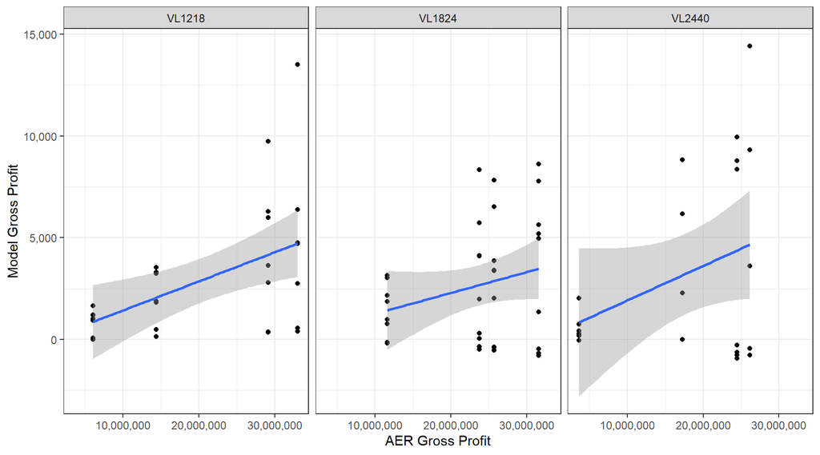

```r
AER_Costs = openxlsx::read.xlsx("Input file/STECF_25 07_EU Fleet Economic and Transversal data_fleet segment level.xlsx", sheet = 2) %>%
             mutate(year = as.character(year)) %>%
             filter(country_code %in% "ITA",
                 year %in% c("2020", "2021", "2022", "2023"),
                 fishing_tech %in% c("DTS"), supra_reg %in% c("MBS"),
                 variable_name %in% c("Gross value of landings",
                                      "Other income",
                                    "Days at sea",
                                    "Personnel costs",
                                    "Value of unpaid labour",
                                    "Energy costs",
                                    "Repair & maintenance costs",
                                    "Other variable costs",
                                    "Other non-variable costs") ) %>%
           rename(VL = vessel_length,  YEAR = year ) %>%
           mutate(variable_name = gsub(" ", "_", variable_name))

AER_Costs_tot = AER_Costs %>%
            dcast(YEAR + VL ~ variable_name, value.var="value") %>%
   mutate(AER_GRP_tot = (Gross_value_of_landings + Other_income)  - (Personnel_costs + Value_of_unpaid_labour + Energy_costs + `Repair_&_maintenance_costs` + Other_variable_costs + `Other_non-variable_costs`))

AER_dayCosts <- AER_Costs_tot %>%
  group_by(YEAR, VL) %>%
  summarise(across( c(
         Gross_value_of_landings,
         Other_income,
          Energy_costs,
        `Other_non-variable_costs`,
        Other_variable_costs,
        Personnel_costs,
        `Repair_&_maintenance_costs`,
        Value_of_unpaid_labour),
      ~ round(.x / Days_at_sea, 2)),.groups = "drop") %>%
  mutate(AER_GRP = (Gross_value_of_landings + Other_income)  - (Personnel_costs + Value_of_unpaid_labour + Energy_costs + `Repair_&_maintenance_costs` + Other_variable_costs + `Other_non-variable_costs`))

write.xlsx(AER_dayCosts, paste0(out_dir,"/Results/AER_dayCosts.xlsx"))



full_model_eco_agg = full_model_eco %>%
                 group_by(YEAR, VL,WF,HARBOUR) %>%
        summarise(vland = sum(value_of_landings, na.rm = T),
                  fishdays_tot = sum(fishdays, na.rm = T),
                  price = mean(Price_Kg, na.rm = T),
          daily_value_of_landings =  vland/fishdays_tot,
           .groups = "drop")



###

col_costs = c("YEAR","VL","Other_income","Energy_costs", "Other_non-variable_costs","Other_variable_costs",
  "Personnel_costs","Repair_&_maintenance_costs","Value_of_unpaid_labour")

full_model_eco_agg_GRP = full_model_eco_agg %>%
                        left_join(AER_dayCosts[,col_costs]) %>%
                   mutate(GRP = round((daily_value_of_landings + Other_income)  - (Personnel_costs + Value_of_unpaid_labour + Energy_costs + `Repair_&_maintenance_costs` + Other_variable_costs + `Other_non-variable_costs`),2))

aer_gv = c("YEAR", "VL","AER_GRP_tot")

GRP_check = full_model_eco_agg_GRP %>%
              group_by(YEAR, VL) %>%
              summarise(GRP =sum(GRP)*1000) %>%
              left_join(AER_Costs_tot[,aer_gv]) %>%
              mutate(rate = AER_GRP_tot / GRP)

full_model_eco_agg_GRP_rescaled <- full_model_eco_agg_GRP %>%
  left_join(
    GRP_check %>% select(YEAR, VL, rate),
    by = c("YEAR", "VL")
  ) %>%
  mutate(GRP_rescaled = GRP * rate)




  full_model_eco_agg_GRP_rescaled %>%
  left_join(AER_Costs_tot[, aer_gv], by = c("YEAR", "VL")) %>%
  ggplot(aes(x = AER_GRP_tot, y = GRP_rescaled))+
  geom_point()+
  geom_smooth(method = "lm")+
  facet_wrap(~VL)+
  xlab("AER Gross Profit")+
  ylab("Model Gross Profit")+
  scale_x_continuous(labels = scales::label_comma())+
  scale_y_continuous(labels = scales::label_comma())+
  theme_bw()
```

# 6 Result and conclusion

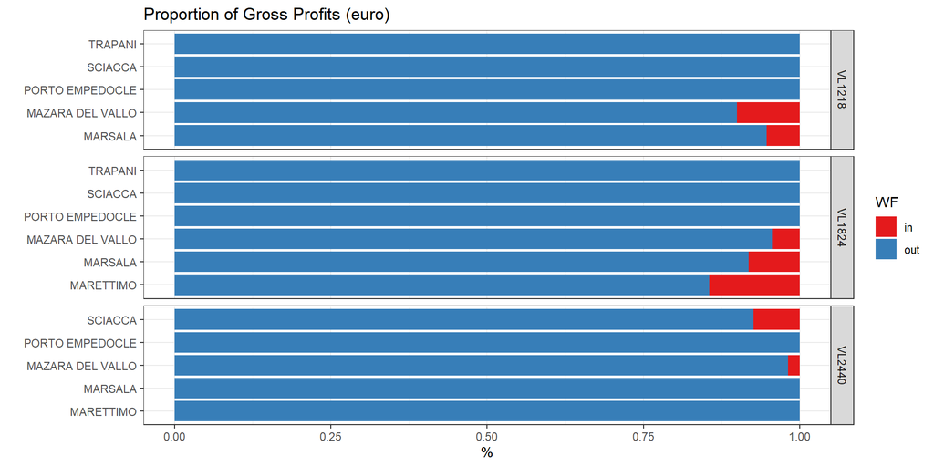

```r
df_prop = full_model_eco_agg_GRP_rescaled %>%
  group_by(HARBOUR, WF, YEAR, VL) %>%
  summarise(GRP_rescaled = sum(GRP_rescaled, na.rm = TRUE), .groups = "drop") %>%
  group_by(HARBOUR, WF, VL) %>%
  summarise(GRP_rescaled = median(GRP_rescaled, na.rm = TRUE), .groups = "drop") %>%
  group_by(HARBOUR, VL) %>%
  mutate(prop = abs(GRP_rescaled) / sum(abs(GRP_rescaled), na.rm = TRUE)) %>%
  ungroup()

ggros =   ggplot(df_prop,
        aes(y = HARBOUR,x = prop,fill = WF)) +
        geom_bar(stat = "identity") +
       facet_grid(VL ~ ., scales = "free_y", space = "free_y") +
       xlab("%") +
       ylab("") +
       scale_fill_brewer(palette = "Set1")+
       ggtitle("Proportion of Gross Profits (euro)") +
       theme_bw()

ggsave(ggros, filename = paste0(out_dir,"/Results/ggros.jpeg"),width = 14, height = 10, units = "cm", dpi = 300)

print(ggros)
```

```r
ggros2 = full_model_eco_agg_GRP_rescaled %>%
  group_by(WF, YEAR, VL, HARBOUR) %>%
  summarise(sum_GRP = sum(abs(GRP_rescaled)), .groups = "drop") %>%
  mutate(sum_GRP_scaled = scales::rescale(sum_GRP, to = c(0, 1000))) %>%
  ggplot(aes(x = HARBOUR, y = sum_GRP_scaled, fill = WF)) +
  geom_boxplot() +
  scale_fill_brewer(palette = "Set1")+
  ylab("Gross Profits (euro) (rescaled 0–1000)") +
  theme_bw() +
  theme(axis.text.x = element_text(angle = 45, hjust = 1))

ggsave(ggros2, filename = paste0(out_dir,"/Results/ggros2.jpeg"),width = 14, height = 10, units = "cm", dpi = 300)


tableGRP = full_model_eco_agg_GRP_rescaled %>%
               mutate(Gross_Profit = abs(GRP_rescaled),
                      Value_of_Landing = round(vland, 3) ) %>%
                dplyr::select(WF, YEAR, VL, HARBOUR, Value_of_Landing,fishdays_tot, Gross_Profit) %>%
                unique()

write.xlsx(tableGRP, paste0(out_dir,"/Results/table_GRP.xlsx"))
```